# Project1 - This is Hip-Hop

```python
from IPython.display import HTML

HTML('''<script>
code_show=true;
function code_toggle() {
 if (code_show){
 $('div.input').hide();
 } else {
 $('div.input').show();
 }
 code_show = !code_show
}
$( document ).ready(code_toggle);
</script>
<form action="javascript:code_toggle()"><input type="submit" value="Click here to toggle on/off the raw code."></form>''')
```

## Project1 - This is Hip-Hop

#### Rui Cao - rc3208

[figure not shown]

## Introduction

It's said that popular music is a reflection of society, an expression of our thoughts, wants, fears, and emotions. Others are of the belief that music is more an expression of artists themseleves. In either case, music can serve as an insight into the human mind in ways that many other mediums cannot. Lyrics and rythms both affect people's mood. Hiphop is a stylized rhythmic music, intinally developed in the United States in 1970s. With hiphop's development, it emerges on the national scene. In 2017, hip-hop has usurped rock as the most consumed and popular musical genre reported by Fores.

What happends in the past 50 years,letting hip-hop so successful? Today, let's figure it out!

```python
import os
import numpy as np
import pandas as pd
import seaborn as sns
import matplotlib.pyplot as plt
import nltk
import pyreadr
from nltk import FreqDist
from nltk.corpus import PlaintextCorpusReader
from wordcloud import WordCloud
from sklearn.decomposition import NMF
from nltk.sentiment.vader import SentimentIntensityAnalyzer
nltk.download('vader_lexicon')
from sklearn.feature_extraction.text import TfidfVectorizer
nltk.download('stopwords')
```

```
True
```

```python
"""
Load processed lyrics data
"""

def read_processed_lyrics() -> pd.DataFrame:
    """
    Load processed lyrics data from file

    return the data frame containing the data
    """
    result = pyreadr.read_r('../data/processed_lyrics.RData')
    return result['dt_lyrics']

processed_lyrics = read_processed_lyrics()
```

```python
processed_lyrics.loc[processed_lyrics["year"]==112,'year']=1998
```

```python
processed_lyrics.loc[processed_lyrics['year']==702,'year'] = 2002
```

# 1. What features are Hip-hop have?

### word frequency

First of all, I analyze words frequency of lyrics in hip-hop music and other genres.

For data visualization, I used heatmap to implement the result.

```python
def times(c):
    if c < 1980:
        return 1970
    elif c < 1990:
        return 1980
    elif c < 2000:
        return 1990
    elif c < 2010:
        return 2000
    elif c < 2020:
        return 2010
    return -1
processed_lyrics['times'] = 0
processed_lyrics['times'] = [times(x) for x in processed_lyrics['year']]
```

```python
processed_lyrics['wordcount'] = [len(x.split()) for x in processed_lyrics['stemmedwords']]
```

```python
word_avg=processed_lyrics.pivot_table(values = ['wordcount'],index=['genre'], columns=['times'], aggfunc=np.mean, fill_value=0)
```

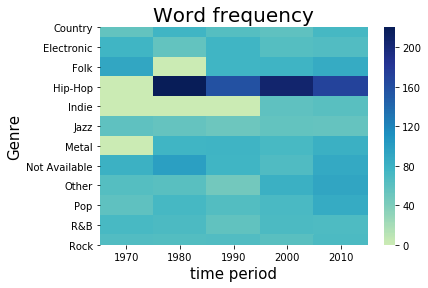

```python
ax = plt.axes()
ax.set(title='Word frequency')
sns.heatmap(word_avg['wordcount'],fmt="d",cmap='YlGnBu',center=processed_lyrics['wordcount'].mean())
plt.title('Word frequency', fontsize=20)
plt.xlabel('time period', fontsize = 15)
plt.ylabel('Genre', fontsize = 15)
plt.show()
```

It is obvious that word frequency of hip-hop is much higher than other genres. On the other word, hip-hop usually contain numerous information in its lyrics. It needs professional rhythmic and rhyming speech skills to perform a great shows

But on the other aspect, the popularity of music is kindly based on how quickly people will memorize it. As an effective way for propagating music, it should be easy for audience to remember the rhythm and lyric. Considering massive contexts in hip-hop lyrics, we are hard to explain why hip-hop becomes the most popular genre in music history.

There are two hypothesis:

1. The lyric pattern is easy to remember, although it contains massive information.
2. The lyric is atttactive enough and meet audience taste.

### Readbility

In this part, I'm going to compare readbility in different genres in order to determine whether those lyrics are easy to remember or not. Generally, there are a lot of indexes used to calculate readability scores. Here, I used multiple functions to caulculate them.

Generally speaking, in the heatmap, the darker the color, the higher the readability score is. That is to say, the lyrics filled with a darker color is harder to read. For hip-hop, the speech filled with the darkest color in all indexes. It is out of our perspective that hiphop is easy to read. So what exactly make hiphop so popular is still undercover.

```python
import textstat
```

```python
smog_ind = []
flesch_kincaid_grade_ind = []
dale_chall_readability_score_ind = []
gunning_fog_ind = []
for _, row in processed_lyrics.iterrows():
    text = row['lyrics']
    smog_ind.append(textstat.smog_index(text))
    flesch_kincaid_grade_ind.append(textstat.flesch_kincaid_grade(text))
    dale_chall_readability_score_ind.append(textstat.dale_chall_readability_score(text))
    gunning_fog_ind.append(textstat.gunning_fog(text))
```

```python
readability = pd.DataFrame()
readability['genre'] = processed_lyrics['genre']
readability['smog_index'] = smog_ind
readability['flesch_kincaid_grade'] = flesch_kincaid_grade_ind
readability['dale_chall_readability_score'] = dale_chall_readability_score_ind
readability['gunning_fog'] = gunning_fog_ind
```

```python
readability_index = readability.pivot_table(values = ['smog_index','flesch_kincaid_grade','dale_chall_readability_score','gunning_fog'],index=['genre'], aggfunc=np.mean, fill_value=0)
```

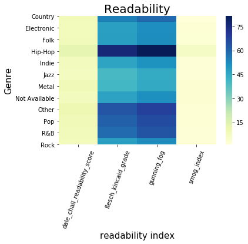

```python
ax = plt.axes()
sns.heatmap(readability_index,fmt="d",cmap='YlGnBu')
plt.title('Readability', fontsize=20)
plt.xlabel('readability index', fontsize = 15)
plt.xticks(rotation=70)
plt.ylabel('Genre', fontsize = 15)
plt.show()
```

```python
readability.plot.bar(x='genre',y='smog_index')
plt.title('Readability Smog Index')
plt.ylabel('Index')
plt.show()
```

[output not shown]

### 2. What Hiphop sings in lyrics?

In this part, I would like to explore whether the context itself attract hiphop audience. I'll see what are hiphop singers' concentrations and focuses. By counting word frequency in all songs and hiphip seperately used wordcloud package,I tried to find the most frequently used words in lyrics. Below are wordclouds of overview of all genres (first picture) and hiphop (second picture)

```python
from PIL import Image
hiphop_mask = np.array(Image.open('../figs/hiphop.png'))
general_mask = np.array(Image.open('../figs/singer.png'))
```

```python
from itertools import chain
from nltk.corpus import stopwords
stop_words = stopwords.words('english')
stop_words.extend(['youre','ill','ive','gotta','ya','yo','yall','uh','em','chorus','gon','shes','rhyme'])

def get_wordcloud(data):
    Words = [word.split() for word in data['stemmedwords']]
    Text = list(chain(*Words))
    Words_dis=FreqDist(Text)

    """
    remove stopword
    """
    for stopword in stop_words:
        if stopword in Words_dis:
            del Words_dis[stopword]
    return Words_dis

#     print(Words_dis.most_common(50))
```

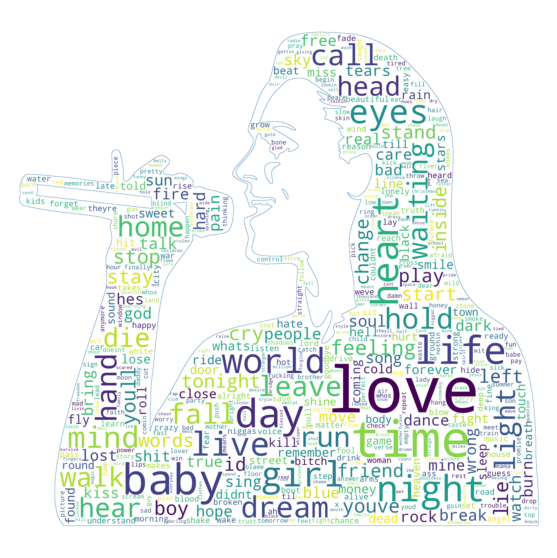

```python
general_wc = get_wordcloud(processed_lyrics)
wordcloud = WordCloud(

        max_words=500,
        scale=3,
        background_color="white",  mask=general_mask,contour_width=3, contour_color='steelblue'
    )

wordcloud.generate_from_frequencies(dict(general_wc))
plt.figure(figsize=(10,10))
plt.imshow(wordcloud,cmap=plt.cm.gray, interpolation='bilinear')
plt.axis("off")
plt.show()
```

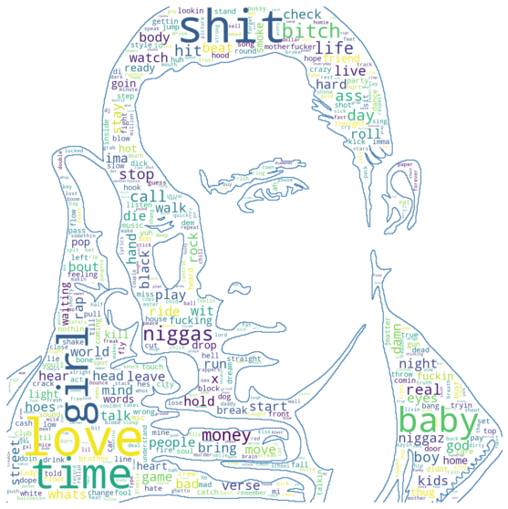

```python
hiphop_wc = get_wordcloud(hiphop)
wordcloud = WordCloud(
        max_words=500,
        scale=2,
        background_color="white", mask=hiphop_mask,contour_width=3, contour_color='steelblue'
    )
wordcloud.generate_from_frequencies(dict(hiphop_wc))
plt.figure(figsize=(10,10))
plt.imshow(wordcloud,cmap=plt.cm.gray, interpolation='bilinear')
plt.axis("off")
plt.show()
```

From these two word clouds, we could see lyrics of hiphop includes girl, money, and some dirty words, which are different from other genres, which reflect more of singers' spiritual world. In the other hand, the words in hiphop are more direct to express singers dissatisfaction of the political and social condition, and unfair treatment to Africa American in the real life.

Are our guess right? To deep dive our assumption, sentiment analysis is used to show whether hiphop is passive and negative or not.

### sentiment analysis

```python
sid = SentimentIntensityAnalyzer()
pos = []
neu = []
neg = []
for i in range(processed_lyrics.shape[0]):

    comp = sid.polarity_scores(processed_lyrics['stemmedwords'][i])
    comp = comp['compound']
    if comp >= 0.5:
        pos.append(1)
        neu.append(0)
        neg.append(0)
    elif comp > -0.5 and comp < 0.5:
        pos.append(0)
        neu.append(1)
        neg.append(0)
    else:
        pos.append(0)
        neu.append(0)
        neg.append(1)
sentiment = pd.DataFrame()
sentiment['genre'] = processed_lyrics['genre']
sentiment['pos'] = pos
sentiment['neu'] = neu
sentiment['neg'] = neg
sentiment_prec = pd.DataFrame()
num_sum = sentiment.groupby(['genre']).count()['pos']
num_pos = sentiment[sentiment['pos']!=0].groupby(['genre']).count()['pos']
num_neu = sentiment[sentiment['neu']!=0].groupby(['genre']).count()['neu']
num_neg = sentiment[sentiment['neg']!=0].groupby(['genre']).count()['neg']
sentiment_prec['genre'] = num_pos.index
sentiment_prec['pos'] = (num_pos.values/num_sum.values)*100
sentiment_prec['neu'] = (num_neu.values/num_sum.values)*100
sentiment_prec['neg'] = (num_neg.values/num_sum.values)*100
```

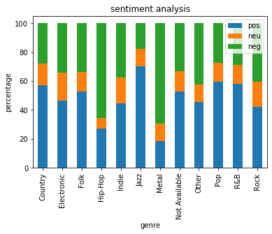

```python
sentiment_prec.plot.bar(x='genre', stacked=True)
plt.title('sentiment analysis')
plt.ylabel('percentage')
plt.show()
```

From this plot, we could see different colors represent different emotions: green for negative, orange for neural, and blue for positive ones. For hiphop, naegative emotion is over 60 percentage. That's to say, we're in the right direction.

## 3. What topics are used in Hiphop?

In this part, we're doing to talk about topic are written in hiphop lyrics.

### Topic modeling

After some adjustments, we divided all lyrics into four main topic: life, love, anger and party. We'll see how those topic change over time.

Topic example:

```python
vectorizer = TfidfVectorizer(stop_words=stop_words,min_df = 0.05)
tfdif = vectorizer.fit_transform(hiphop['stemmedwords'])
nmf = NMF(n_components=4)
topic_values = nmf.fit_transform(tfdif)
```

```python
for topic_num,topic in enumerate(nmf.components_):
    message = 'topic #{} '.format(topic_num+1)
    message += ' '.join(vectorizer.get_feature_names()[i] for i in topic.argsort()[:-11 :-1])
    print(message)
```

```
topic #1 time life day people live mind world rock call stop
topic #2 girl baby tonight body night call shake lady time boy
topic #3 niggas bitch shit ass hoes motherfucker money fuckin wit niggaz
topic #4 love baby heart life time hurt day fall night feeling
```

```python
topic_labels = ['life','party','anger','love']
```

```python
topic_df = pd.DataFrame(topic_values,columns=topic_labels)
```

```python
hiphop = hiphop.join(topic_df)
```

```python
hiphop.loc[hiphop['life']>=0.05,'life']=1
hiphop.loc[hiphop['party']>=0.05,'party']=1
hiphop.loc[hiphop['anger']>=0.05,'anger']=1
hiphop.loc[hiphop['love']>=0.05,'love']=1
hiphop.loc[hiphop['life']<0.05,'life']=0
hiphop.loc[hiphop['party']<0.05,'party']=0
hiphop.loc[hiphop['anger']<0.05,'anger']=0
hiphop.loc[hiphop['love']<0.05,'love']=0
```

```python
year_topics = hiphop.groupby('year').sum().reset_index()
```

```python
year_topics['times'] = [times(x) for x in year_topics['year']]
```

```python
year_topics_heatmap = year_topics.pivot_table(values = ['life','party','anger','love'],index=['times'], aggfunc=np.sum, fill_value=0)
```

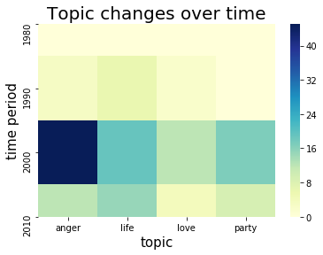

```python
ax = plt.axes()
sns.heatmap(year_topics_heatmap,fmt="d",cmap='YlGnBu')
plt.title('Topic changes over time', fontsize=20)
plt.xlabel('topic', fontsize = 15)
plt.ylabel('time period', fontsize = 15)
plt.show()
```

### Summary

By analysing lyrics, we figure out that hiphop can serve as both an insight into the human mind and society. It is a symbol of freedom of African American